A guide for our guests

# Welcome to Brodrick Road

## Contents

## Who lived here?

The house was built in the Victorian era. We can learn about the people who have lived here over the years from the census.

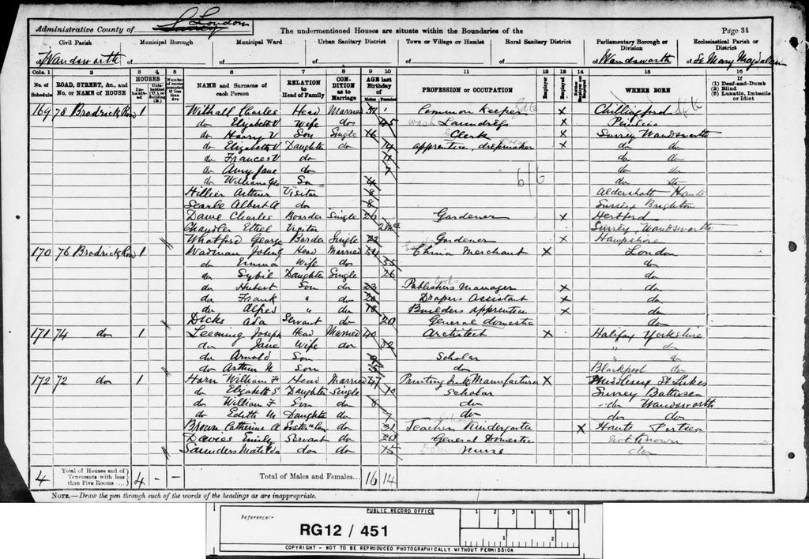

1891Census The National Archives · RG12/451

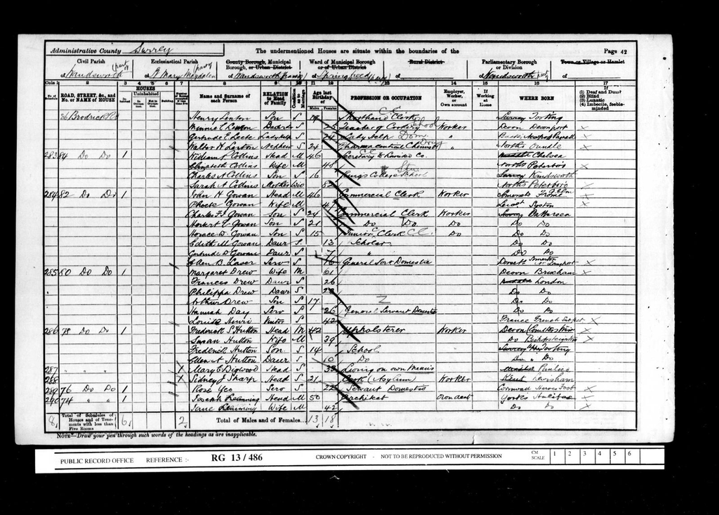

1901Census The National Archives · RG13/486

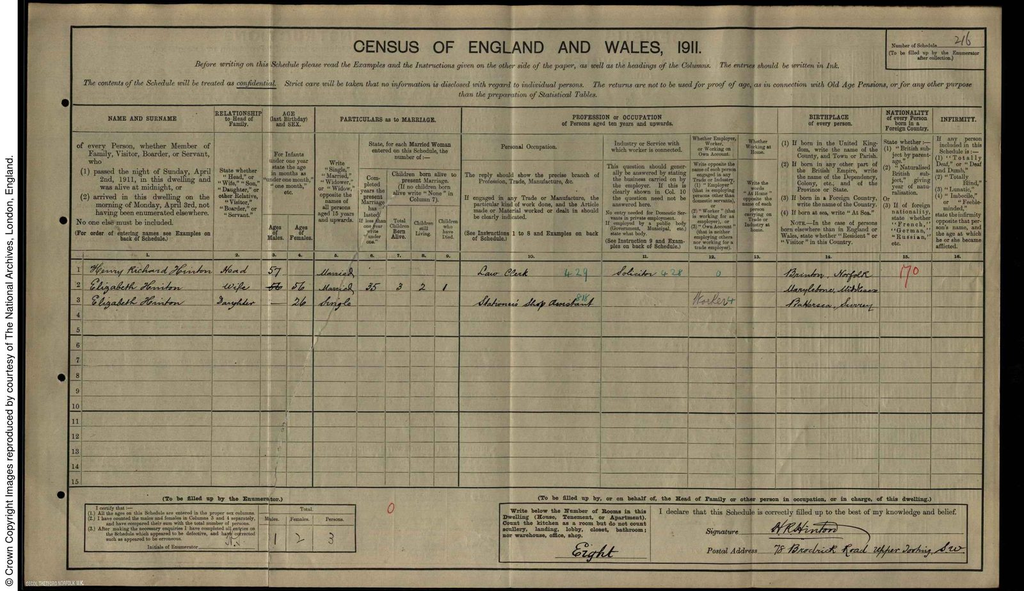

1911Census The National Archives · RG14

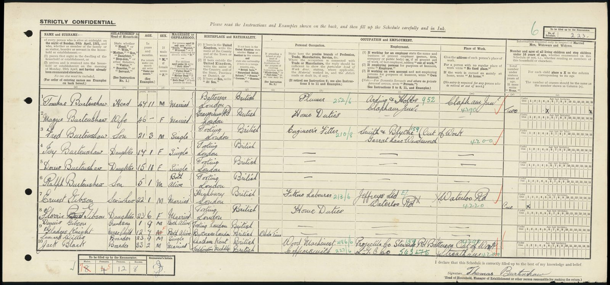

1921Census The National Archives · RG15

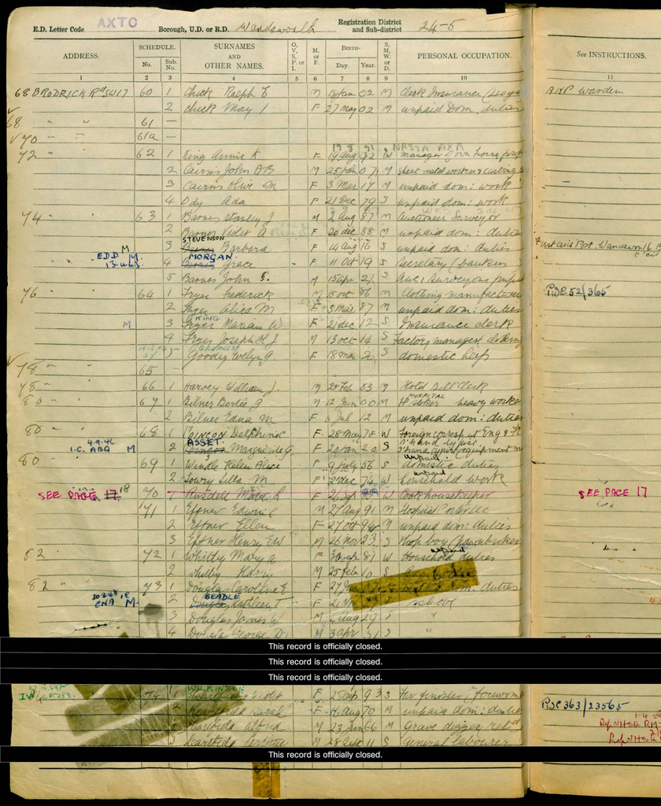

19391939 Register The National Archives · R39

### Questions

1. What do you think a “common keeper” is? (Hint: what are the big green spaces nearby called?)
2. What year were there the most people living in the house? Were they all from the same family?
3. What is a “nurse child”? What year was there a nurse child living in the house?
4. What does “boarder” mean?
5. What does “head of family” mean? Can you find any women listed as “head”?

### Match the job to the person

Can you match these people to their jobs?

People

- Charles Withall
- Frederick S Hutton
- Sidney J Sharp
- Thomas Burtenshaw
- William Harvey

Jobs

- Plumber
- Asylum cook
- Common keeper
- Hotel bill clerk
- Upholsterer

**Show answers**

Withall — keeper of the common (1891) · Hutton — upholsterer (1901) · Sharp — cook at an asylum (1901) · Burtenshaw — plumber, at Arding & Hobbs in Clapham Junction (1921) · Harvey — hotel bill clerk (1939).

Census images © Crown Copyright, reproduced by courtesy of The National Archives, for personal and family use.

Contents

## Historic maps

We can learn about the history of the house and local area using old maps.

[figure not shown]

1869–74Ordnance Survey

[figure not shown]

1896Ordnance Survey

[figure not shown]

1916–19Ordnance Survey

[figure not shown]

1930sOrdnance Survey

[figure not shown]

1947–52Ordnance Survey

[figure not shown]

1950s–70sOrdnance Survey

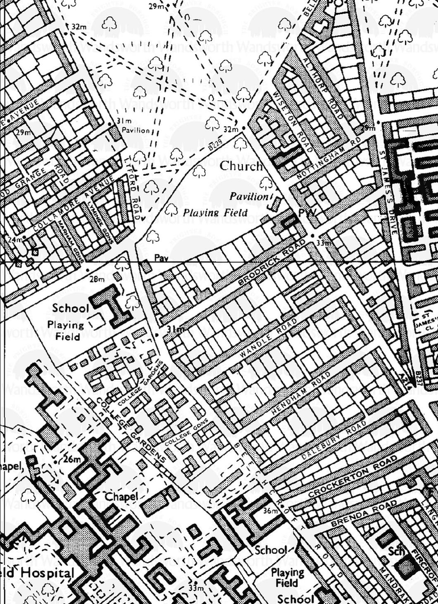

1976–95Ordnance Survey

### Questions

1. When do you think our house was built?
2. Find the County Lunatic Asylum on the oldest map. What do you think that name meant? Is it a word we’d use today? What is this place called now?
3. Find the nearest railway station to the house. What is it called? Where can you get to from this station?
4. When was the school at the end of our road built?

Maps © Crown copyright. All rights reserved. Reproduced from the Wandsworth Borough Council mapping service under Licence No. LA 1000019270 (2025), for personal and family use.

Contents

## Treasure hunt

Can you find the things below?

### The servants’ bells

See if you can find which pull rings which bell!

### The folly

A folly is a decorative, non-practical building in a garden. Ours is looked after by our two garden gnomes.

### The snail faucet

### Musical side-table

### Animal skulls

How many can you find? What animals do you think they come from?

### Ostrich egg

### Fruit trees

We have fig, apple and quince. If you find any ripe fruit, help yourself!

### Fireplace trivet

How many can you find? What do you think the tools around the fireplace are for?

Contents

Enjoy your stay!

Tap anywhere to close

[figure not shown]